# Part II - Ford Go Bike Dataset Exploration

## by (ODINIGWE CHINYERE ROSEMARY)

## Investigation Overview

> For this presentation,i will focus on the distribution of the key features of interest such as
> - The user demographics with respect to age,usertype and gender.
> - The distribution of trips across days of the week and hours of the day.
> - Usertype and gender relationship with duration and age
> - The duration of user type and genders across the days of the week
> - The top 3 stations and its relationship to usertype and gender

## Dataset Overview

> This dataset was provided by Udacity and it includes information regarding 183,000 rides made in Ford Go bike-sharing system covering the greater San Francisco Bay area. The data features include trip duration (secs),trip start and end time,start and end stations,customer type, gender, birth year and some additional variables.

## Age Distribution of users

> The ages from this dataset contained some outliers such as Max age(141), after setting the upper bound to 65 as the initial data was rightly skewe,The majority of the users were observed to be between the age of 25-35 as shown below.

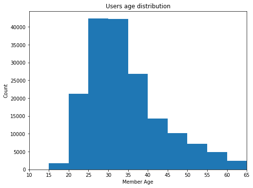

## User Type and Gender distribution

> Ford Go bike users for Feb 2019 is composed of more **Subcribers and Male** genders as shown in plots below.

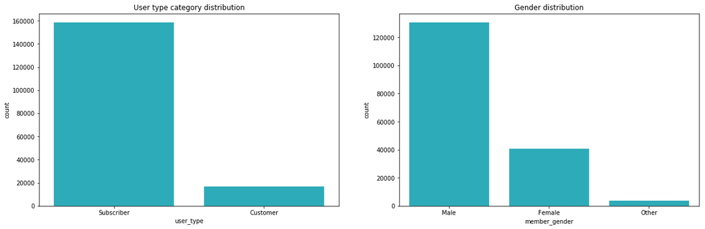

## Usage frequency across weekdays and hours.

> The usage frequency peaks during the week is on Thursday and Tuesday.The peak hours are between (8-9)hrs for the morning hours of the day and (17-18)hrs for the evening hrs of the day.This can be attributed to the work timeline in san francisco.

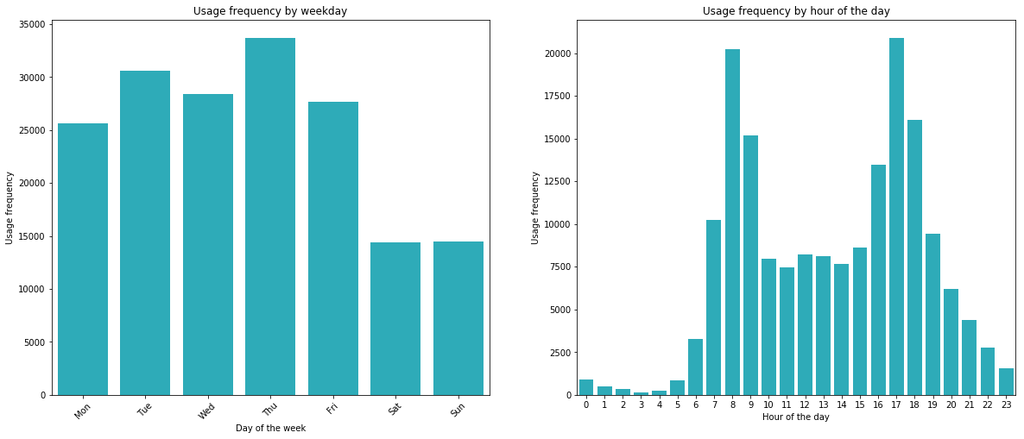

## Usertype and Gender relationship with age and duration.

> The users who are Customer have longer bike trip on average as compared to users who are Subscribers and Female users have longer bike trip on average as compared to Male users while The average age of the Customer and Subscriber users is approximately same and the average age of the Male users is higher than the average age of the Female users

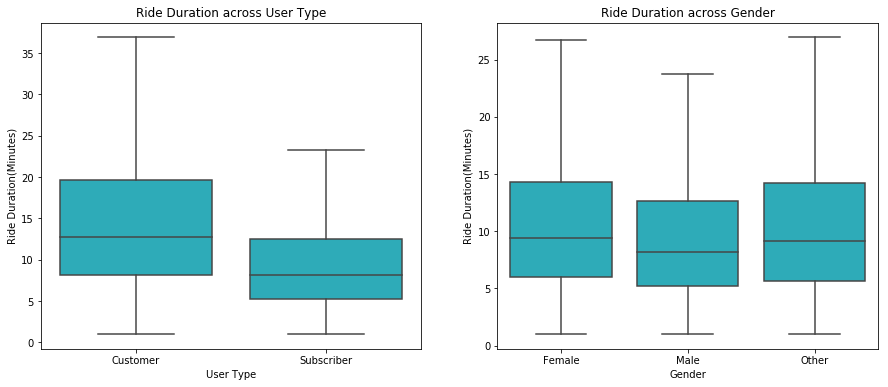

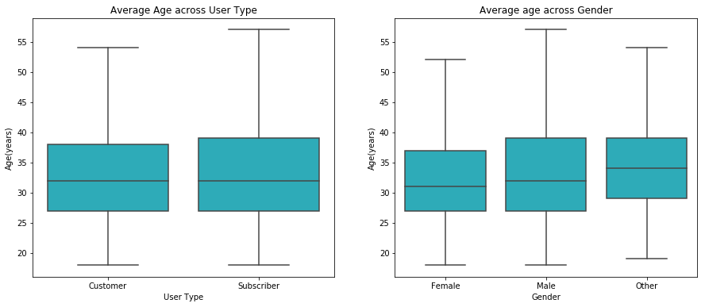

## Trip durations of Usertype and Gender across the days of the week.

> Customers have higher average trip duration for all days of the week, although they spend longer times on weekends than on weekdays.Female users have higher average trip duration for all days of the week and also spend longer times on weekends than on weekdays

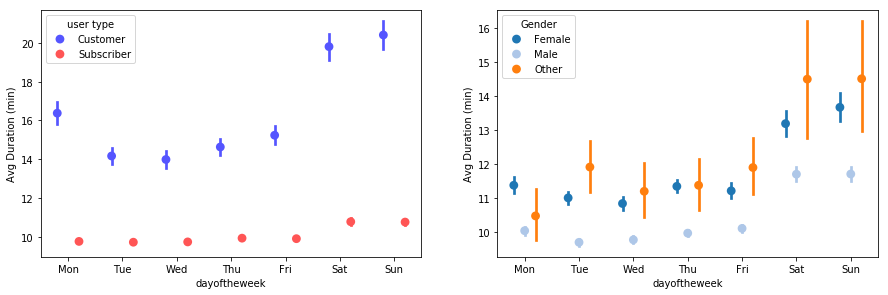

## The top 3 stations and its relationship to usertype and gender.

> The male subscribers are majority in numbers in all the 3 stations compared to the female subscribers.The female subscriber for Market st at 10th st is higher than that of other stationss

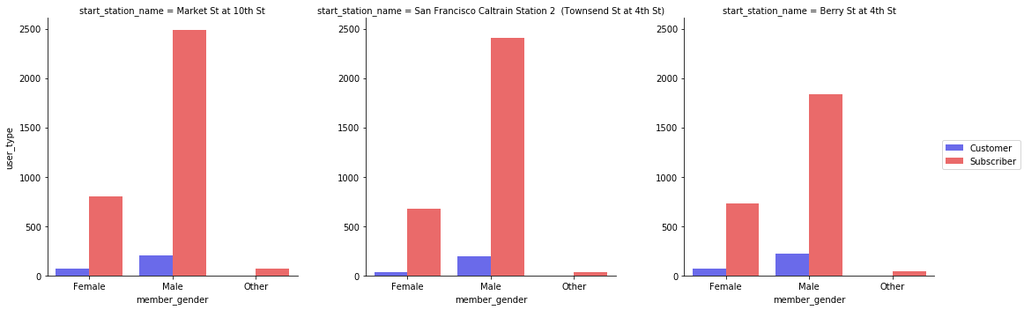